# TidyModels in R with Malaria Data Application

Tatiana Benaglia and Samara Kiihl

Departament of Statistics - IMECC - UNICAMP

August 29th 2024

# 1 Introduction

This is a supporting material for the tutorial presented during the Artificial Intelligence for Malaria (and Infectious Diseases) Modelling in Brazil and Latin America ([AIMM 2024](https://sally.ufba.br/AIMM2024.html)) at [IMECC, UNICAMP](https://ime.unicamp.br/).

Source files are available on https://github.com/samarafk/AIMM2024.

The video os the presentation: https://www.youtube.com/watch?v=t75nrLtK5Oo

The slides presented:

[01- Introduction](https://drive.google.com/file/d/1A61GVdcfWuoSSZBpP3Dh2cxCHDadM7Aw/view?usp=drive_link)

[02 - Tidymodels Structure](https://drive.google.com/file/d/1oupHAdI7ILNQjhv30TjL8zjluBm6Uh9b/view?usp=drive_link)

[03 - Evaluating and Comparing Models](https://drive.google.com/file/d/1psdR1dYgECNz9hqUDTVGvjWZ7KUC8uqn/view?usp=drive_link)

[04 - Tuning](https://drive.google.com/file/d/1qxnM2rJSkKBCHoWl4yWhjvE6wPFDd0_Y/view?usp=drive_link)

# 2 Dataset

The dataset used in this example is available from Adeboye, Abimbola, and Folorunso (2020).

We start by loading the `tidyverse` package and importing the dataset:

```r
library(tidyverse)
malaria <- read_csv("https://ars.els-cdn.com/content/image/1-s2.0-S2352340919313526-mmc1.csv")
```

Quick information about the dataset:

```r
malaria %>% glimpse()
```

```
## Rows: 337
## Columns: 18
## $ age            <dbl> 3, 3, 3, 4, 4, 4, 4, 5, 5, 8, 8, 8, 8, 9, 9, 9, 9, 10, …
## $ sex            <dbl> 1, 0, 0, 1, 0, 1, 0, 1, 0, 0, 1, 0, 0, 1, 0, 1, 1, 0, 0…
## $ fever          <dbl> 1, 1, 1, 1, 1, 0, 1, 1, 1, 1, 0, 1, 1, 1, 1, 0, 1, 0, 1…
## $ cold           <dbl> 1, 1, 1, 1, 1, 0, 1, 0, 0, 1, 0, 1, 0, 0, 1, 0, 1, 0, 0…
## $ rigor          <dbl> 0, 1, 1, 0, 1, 0, 1, 1, 1, 1, 0, 0, 1, 0, 0, 1, 1, 1, 0…
## $ fatigue        <dbl> 1, 1, 1, 1, 0, 1, 1, 1, 1, 0, 1, 1, 1, 1, 0, 1, 0, 1, 0…
## $ headace        <dbl> 1, 1, 1, 0, 1, 1, 0, 0, 1, 1, 1, 0, 1, 1, 1, 0, 0, 1, 1…
## $ bitter_tongue  <dbl> 1, 1, 0, 0, 0, 0, 0, 0, 1, 1, 1, 0, 0, 1, 0, 0, 1, 1, 0…
## $ vomitting      <dbl> 0, 0, 0, 0, 0, 0, 0, 1, 0, 0, 0, 1, 0, 0, 0, 0, 1, 0, 0…
## $ diarrhea       <dbl> 1, 1, 1, 0, 0, 1, 0, 1, 0, 1, 0, 0, 0, 0, 0, 0, 0, 0, 0…
## $ Convulsion     <dbl> 1, 0, 1, 0, 1, 0, 0, 0, 1, 0, 0, 0, 0, 1, 1, 0, 0, 0, 0…
## $ Anemia         <dbl> 0, 0, 0, 0, 0, 1, 0, 1, 0, 0, 1, 1, 0, 0, 0, 0, 1, 1, 0…
## $ jundice        <dbl> 1, 0, 0, 1, 1, 0, 0, 1, 0, 1, 1, 1, 1, 0, 1, 0, 1, 0, 0…
## $ cocacola_urine <dbl> 1, 1, 1, 0, 1, 0, 0, 0, 0, 0, 1, 1, 1, 0, 1, 0, 1, 1, 1…
## $ hypoglycemia   <dbl> 1, 1, 1, 1, 1, 0, 0, 0, 1, 1, 1, 1, 1, 1, 1, 1, 1, 1, 1…
## $ prostraction   <dbl> 0, 0, 0, 0, 0, 0, 0, 0, 0, 0, 1, 0, 0, 0, 1, 0, 0, 0, 0…
## $ hyperpyrexia   <dbl> 0, 0, 0, 1, 0, 0, 0, 0, 0, 0, 0, 0, 0, 0, 0, 0, 1, 0, 0…
## $ severe_maleria <dbl> 0, 0, 1, 0, 0, 1, 0, 0, 0, 0, 0, 1, 0, 0, 0, 1, 0, 0, 0…
```

We have $n=337$ observations.

Let’s quickly rename one of the variables:

```r
malaria <- malaria %>% rename(severity = severe_maleria)
```

The first 10 observations:

```r
library(kableExtra)
malaria %>% head(10) %>% kable(booktabs = TRUE)
```

| age | sex | fever | cold | rigor | fatigue | headace | bitter_tongue | vomitting | diarrhea | Convulsion | Anemia | jundice | cocacola_urine | hypoglycemia | prostraction | hyperpyrexia | severity |
| --- | --- | --- | --- | --- | --- | --- | --- | --- | --- | --- | --- | --- | --- | --- | --- | --- | --- |
| 3 | 1 | 1 | 1 | 0 | 1 | 1 | 1 | 0 | 1 | 1 | 0 | 1 | 1 | 1 | 0 | 0 | 0 |
| 3 | 0 | 1 | 1 | 1 | 1 | 1 | 1 | 0 | 1 | 0 | 0 | 0 | 1 | 1 | 0 | 0 | 0 |
| 3 | 0 | 1 | 1 | 1 | 1 | 1 | 0 | 0 | 1 | 1 | 0 | 0 | 1 | 1 | 0 | 0 | 1 |
| 4 | 1 | 1 | 1 | 0 | 1 | 0 | 0 | 0 | 0 | 0 | 0 | 1 | 0 | 1 | 0 | 1 | 0 |
| 4 | 0 | 1 | 1 | 1 | 0 | 1 | 0 | 0 | 0 | 1 | 0 | 1 | 1 | 1 | 0 | 0 | 0 |
| 4 | 1 | 0 | 0 | 0 | 1 | 1 | 0 | 0 | 1 | 0 | 1 | 0 | 0 | 0 | 0 | 0 | 1 |
| 4 | 0 | 1 | 1 | 1 | 1 | 0 | 0 | 0 | 0 | 0 | 0 | 0 | 0 | 0 | 0 | 0 | 0 |
| 5 | 1 | 1 | 0 | 1 | 1 | 0 | 0 | 1 | 1 | 0 | 1 | 1 | 0 | 0 | 0 | 0 | 0 |
| 5 | 0 | 1 | 0 | 1 | 1 | 1 | 1 | 0 | 0 | 1 | 0 | 0 | 0 | 1 | 0 | 0 | 0 |
| 8 | 0 | 1 | 1 | 1 | 0 | 1 | 1 | 0 | 1 | 0 | 0 | 1 | 0 | 1 | 0 | 0 | 0 |

The response variable is `severity`. `tidymodels` expects the outcome to be a factor and it also treats the first level as the event:

```r
malaria <- malaria %>%
  mutate(severity = factor(severity)) %>%
  mutate(severity = relevel(severity, ref = "1"))
```

# 3 Data Splitting

We now load the `tidymodels` package to start our analysis. The first step is to split the data into training and testing datasets.

We use the function `initial_split()`. By default, this function splits the data so that 75% is training and 25% is testing. Here, we use 80% for training, so we specify this by setting `prop = 0.8`.

Stratified sampling is done through the `strata` argument. Stratification ensures that the test data maintains a distribution close to that of the training data.

As the separation between training and testing is done randomly, it is important to use `set.seed()` to always guarantee the same division of data when executing the code again:

```r
library(tidymodels)
tidymodels_prefer()

set.seed(1234)
malaria_split <- initial_split(malaria, prop = 0.8, strata = severity)
```

The functions `training()` and `testing()` are used to extract the training and testing datasets, respectively:

```r
malaria_train <- training(malaria_split)
malaria_test <- testing(malaria_split)
```

More details about splitting the dataset into training and testing are discussed in the books by Hastie, Tibshirani, and Friedman (2001) and James et al. (2013).

We can perform exploratory analysis as usual in the training dataset. For instance, what is the distribution of the outcome for the training dataset?

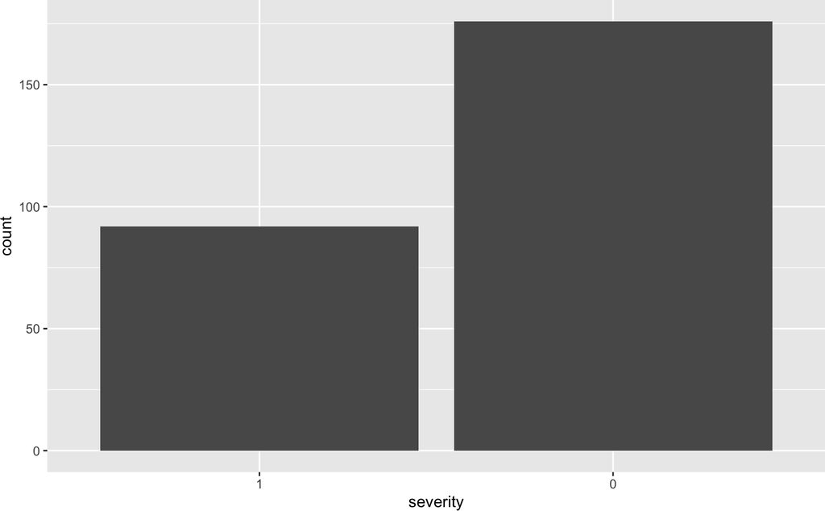

```r
malaria_train %>%
  ggplot(aes(x = severity)) +
  geom_bar()
```

Is the age distribution similar between the two malaria severity conditions?

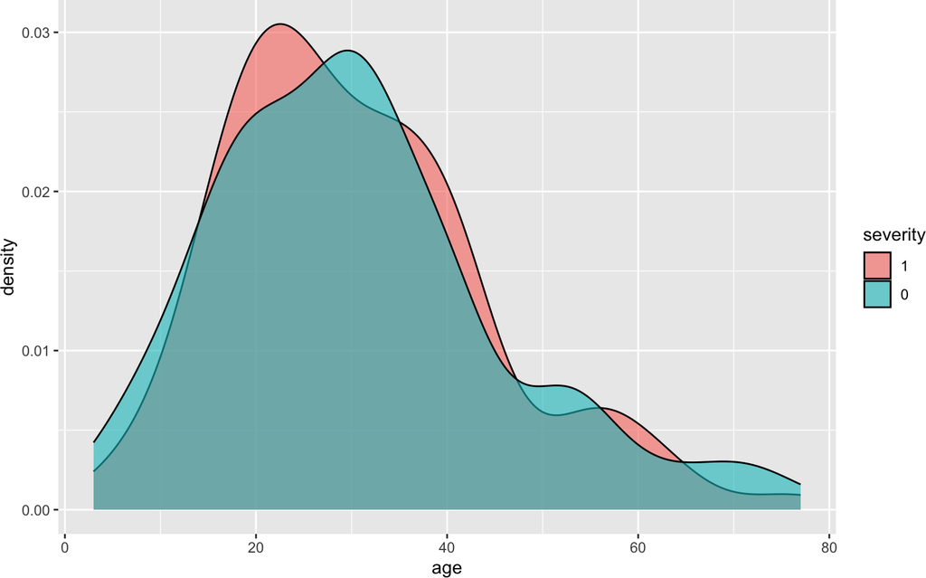

```r
malaria_train %>%
  ggplot(aes(x = age, fill = severity, group = severity)) +
  geom_density(position = "identity", alpha = .6)
```

# 4 Model

We have the following steps when using `tidymodels` to specify a model:

1. Choose a *model*
2. Specify and *engine*
3. Set the *mode*

For instance, if we want to specify a logistic regression model, we use:

```r
logistic_reg()
```

```
## Logistic Regression Model Specification (classification)
##
## Computational engine: glm
```

After specifying the funcional form of the model, we need to choose the engine:

```r
args(logistic_reg)
```

```
## function (mode = "classification", engine = "glm", penalty = NULL,
##     mixture = NULL)
## NULL
```

Here we see that the *default* for `logistic_reg()` is `glm` (generalized linear models), but other models are also available.

Is we want a logistic regression model via lasso and elastic-net regularized generalized linear models:

```r
logistic_reg() %>%
   set_engine("glmnet")
```

```
## Logistic Regression Model Specification (classification)
##
## Computational engine: glmnet
```

All available models are listed in the website: https://www.tidymodels.org/find/parsnip/

# 5 Recipes

Before proceeding to adjust/train the model, the data is pre-processed:

- Some **models** require predictors to have certain characteristics or certain formats.
- Some **variables** require some type of transformation.

To do this, `tidymodels` uses what is called a recipe (`recipe`).

First simple recipe:

```r
rec_simple <- recipe(severity ~ ., data = malaria_train)
```

In the example above, the `recipe()` function defines the response variable and the predictors through the formula.

```r
rec_simple %>% summary() %>% kable(booktabs = TRUE)
```

| variable | type | role | source |
| --- | --- | --- | --- |
| age | double , numeric | predictor | original |
| sex | double , numeric | predictor | original |
| fever | double , numeric | predictor | original |
| cold | double , numeric | predictor | original |
| rigor | double , numeric | predictor | original |
| fatigue | double , numeric | predictor | original |
| headace | double , numeric | predictor | original |
| bitter_tongue | double , numeric | predictor | original |
| vomitting | double , numeric | predictor | original |
| diarrhea | double , numeric | predictor | original |
| Convulsion | double , numeric | predictor | original |
| Anemia | double , numeric | predictor | original |
| jundice | double , numeric | predictor | original |
| cocacola_urine | double , numeric | predictor | original |
| hypoglycemia | double , numeric | predictor | original |
| prostraction | double , numeric | predictor | original |
| hyperpyrexia | double , numeric | predictor | original |
| severity | factor , unordered, nominal | outcome | original |

The preprocessing steps of a recipe use the training data for calculations. Types of calculations in processing:

- Levels of a categorical variable
- Evaluate whether a column has zero (constant) variance - `step_zv()`
- Calculate mean and standard deviation for normalization
- Transform the new data onto the principal components obtained by the training data.

Another recipe example:

```r
malaria_rec <- recipe(severity ~ ., data = malaria_train) %>%
  step_poly(age, degree = 2)
```

The following table presents the data pre-processed according to the recipe above:

| severity | sex | fever | cold | rigor | fatigue | headace | bitter_tongue | vomitting | diarrhea | Convulsion | Anemia | jundice | cocacola_urine | hypoglycemia | prostraction | hyperpyrexia | age_poly_1 | age_poly_2 |
| --- | --- | --- | --- | --- | --- | --- | --- | --- | --- | --- | --- | --- | --- | --- | --- | --- | --- | --- |
| 0 | 0 | 1 | 1 | 1 | 1 | 1 | 1 | 0 | 1 | 0 | 0 | 0 | 1 | 1 | 0 | 0 | -0.116 | 0.179 |
| 0 | 1 | 1 | 1 | 0 | 1 | 0 | 0 | 0 | 0 | 0 | 0 | 1 | 0 | 1 | 0 | 1 | -0.112 | 0.166 |
| 0 | 0 | 1 | 1 | 1 | 0 | 1 | 0 | 0 | 0 | 1 | 0 | 1 | 1 | 1 | 0 | 0 | -0.112 | 0.166 |
| 0 | 1 | 1 | 0 | 1 | 1 | 0 | 0 | 1 | 1 | 0 | 1 | 1 | 0 | 0 | 0 | 0 | -0.107 | 0.153 |
| 0 | 0 | 1 | 1 | 1 | 0 | 1 | 1 | 0 | 1 | 0 | 0 | 1 | 0 | 1 | 0 | 0 | -0.095 | 0.116 |
| 0 | 1 | 0 | 0 | 0 | 1 | 1 | 1 | 0 | 0 | 0 | 1 | 1 | 1 | 1 | 1 | 0 | -0.095 | 0.116 |
| 0 | 0 | 1 | 0 | 1 | 1 | 1 | 0 | 0 | 0 | 0 | 0 | 1 | 1 | 1 | 0 | 0 | -0.095 | 0.116 |
| 0 | 1 | 1 | 0 | 0 | 1 | 1 | 1 | 0 | 0 | 1 | 0 | 0 | 0 | 1 | 0 | 0 | -0.091 | 0.104 |
| 0 | 0 | 1 | 1 | 0 | 0 | 1 | 0 | 0 | 0 | 1 | 0 | 1 | 1 | 1 | 1 | 0 | -0.091 | 0.104 |
| 0 | 0 | 0 | 0 | 1 | 1 | 1 | 1 | 0 | 0 | 0 | 1 | 0 | 1 | 1 | 0 | 0 | -0.086 | 0.093 |

# 6 Workflow

Managing a model specified with `parsnip` (`model` + `engine` + `mode`) and preprocessing steps using `recipes` can be challenging.

To do this, `tidymodels` proposes the use of the `workflow()` function, which has two optional arguments:

- `preprocessor`: can be a formula or a recipe
- `spec`: model specified with `parsnip`

Let’s specify a logistic regression model:

```r
logreg_spec <- logistic_reg() %>%
  set_engine("glm", family = "binomial") %>%
  set_mode("classification")
```

The recipe to be applied is in the `malaria_rec` object.

Let’s add these two pieces of information to the *workflow*:

```r
logreg_wf <- workflow(malaria_rec, logreg_spec)
```

The `fit()` function can be used to fit the model using the training data:

```r
logreg_fit <- logreg_wf %>% fit(data = malaria_train)
logreg_fit
```

```
## ══ Workflow [trained] ══════════════════════════════════════════════════════════
## Preprocessor: Recipe
## Model: logistic_reg()
##
## ── Preprocessor ────────────────────────────────────────────────────────────────
## 1 Recipe Step
##
## • step_poly()
##
## ── Model ───────────────────────────────────────────────────────────────────────
##
## Call:  stats::glm(formula = ..y ~ ., family = ~"binomial", data = data)
##
## Coefficients:
##    (Intercept)             sex           fever            cold           rigor
##        2.36709        -0.29587        -0.07531        -0.35300        -0.11476
##        fatigue         headace   bitter_tongue       vomitting        diarrhea
##       -0.49982        -0.92269         0.26280        -0.31354        -0.40748
##     Convulsion          Anemia         jundice  cocacola_urine    hypoglycemia
##        0.48892         0.27191        -0.03444        -0.29044        -0.59601
##   prostraction    hyperpyrexia      age_poly_1      age_poly_2
##        0.81061        -0.02728        -0.89869         2.71010
##
## Degrees of Freedom: 267 Total (i.e. Null);  249 Residual
## Null Deviance:       344.7
## Residual Deviance: 316.8     AIC: 354.8
```

The `tidy()` function from the `broom` package summarizes the most important information of a model using the *tidy* concept:

```r
logreg_fit %>% tidy(conf.int = TRUE) %>%
  kable(booktabs = TRUE)
```

| term | estimate | std.error | statistic | p.value | conf.low | conf.high |
| --- | --- | --- | --- | --- | --- | --- |
| (Intercept) | 2.3670890 | 0.7063828 | 3.3510002 | 0.0008052 | 1.0274673 | 3.8089201 |
| sex | -0.2958689 | 0.2894746 | -1.0220891 | 0.3067388 | -0.8691092 | 0.2684669 |
| fever | -0.0753123 | 0.3209197 | -0.2346765 | 0.8144598 | -0.7152678 | 0.5477036 |
| cold | -0.3529982 | 0.2842946 | -1.2416634 | 0.2143608 | -0.9170214 | 0.2001822 |
| rigor | -0.1147613 | 0.3012887 | -0.3809013 | 0.7032765 | -0.7041235 | 0.4803683 |
| fatigue | -0.4998153 | 0.2893307 | -1.7274878 | 0.0840801 | -1.0723704 | 0.0646512 |
| headace | -0.9226880 | 0.3315164 | -2.7832347 | 0.0053820 | -1.5930523 | -0.2884397 |
| bitter_tongue | 0.2628021 | 0.2876441 | 0.9136360 | 0.3609081 | -0.2951600 | 0.8352371 |
| vomitting | -0.3135371 | 0.5117889 | -0.6126298 | 0.5401212 | -1.3048736 | 0.7248310 |
| diarrhea | -0.4074835 | 0.2876250 | -1.4167179 | 0.1565654 | -0.9729618 | 0.1573100 |
| Convulsion | 0.4889156 | 0.3025459 | 1.6160048 | 0.1060933 | -0.0953892 | 1.0939984 |
| Anemia | 0.2719093 | 0.2914961 | 0.9328057 | 0.3509203 | -0.2951484 | 0.8507651 |
| jundice | -0.0344386 | 0.2946603 | -0.1168757 | 0.9069585 | -0.6185333 | 0.5396723 |
| cocacola_urine | -0.2904417 | 0.2818125 | -1.0306201 | 0.3027190 | -0.8476280 | 0.2596418 |
| hypoglycemia | -0.5960134 | 0.4523270 | -1.3176606 | 0.1876173 | -1.5387930 | 0.2539197 |
| prostraction | 0.8106059 | 0.3560949 | 2.2763759 | 0.0228235 | 0.1348043 | 1.5387832 |
| hyperpyrexia | -0.0272814 | 0.4204939 | -0.0648793 | 0.9482701 | -0.8376733 | 0.8242539 |
| age_poly_1 | -0.8986936 | 2.3725277 | -0.3787916 | 0.7048426 | -5.5280794 | 3.8406802 |
| age_poly_2 | 2.7101021 | 2.3878718 | 1.1349445 | 0.2563986 | -1.8205447 | 7.6292376 |

```r
logreg_fit %>% tidy(conf.int = TRUE, exponentiate = TRUE) %>%
  kable(booktabs = TRUE)
```

| term | estimate | std.error | statistic | p.value | conf.low | conf.high |
| --- | --- | --- | --- | --- | --- | --- |
| (Intercept) | 10.6662972 | 0.7063828 | 3.3510002 | 0.0008052 | 2.7939806 | 45.101705 |
| sex | 0.7438850 | 0.2894746 | -1.0220891 | 0.3067388 | 0.4193249 | 1.307958 |
| fever | 0.9274538 | 0.3209197 | -0.2346765 | 0.8144598 | 0.4890611 | 1.729277 |
| cold | 0.7025785 | 0.2842946 | -1.2416634 | 0.2143608 | 0.3997078 | 1.221625 |
| rigor | 0.8915790 | 0.3012887 | -0.3809013 | 0.7032765 | 0.4945418 | 1.616670 |
| fatigue | 0.6066427 | 0.2893307 | -1.7274878 | 0.0840801 | 0.3421964 | 1.066787 |
| headace | 0.3974493 | 0.3315164 | -2.7832347 | 0.0053820 | 0.2033041 | 0.749432 |
| bitter_tongue | 1.3005693 | 0.2876441 | 0.9136360 | 0.3609081 | 0.7444125 | 2.305361 |
| vomitting | 0.7308572 | 0.5117889 | -0.6126298 | 0.5401212 | 0.2712068 | 2.064382 |
| diarrhea | 0.6653224 | 0.2876250 | -1.4167179 | 0.1565654 | 0.3779619 | 1.170358 |
| Convulsion | 1.6305471 | 0.3025459 | 1.6160048 | 0.1060933 | 0.9090191 | 2.986190 |
| Anemia | 1.3124679 | 0.2914961 | 0.9328057 | 0.3509203 | 0.7444211 | 2.341438 |
| jundice | 0.9661476 | 0.2946603 | -0.1168757 | 0.9069585 | 0.5387340 | 1.715445 |
| cocacola_urine | 0.7479331 | 0.2818125 | -1.0306201 | 0.3027190 | 0.4284300 | 1.296466 |
| hypoglycemia | 0.5510039 | 0.4523270 | -1.3176606 | 0.1876173 | 0.2146400 | 1.289068 |
| prostraction | 2.2492705 | 0.3560949 | 2.2763759 | 0.0228235 | 1.1443128 | 4.658918 |
| hyperpyrexia | 0.9730874 | 0.4204939 | -0.0648793 | 0.9482701 | 0.4327162 | 2.280179 |
| age_poly_1 | 0.4071011 | 2.3725277 | -0.3787916 | 0.7048426 | 0.0039736 | 46.557133 |
| age_poly_2 | 15.0308103 | 2.3878718 | 1.1349445 | 0.2563986 | 0.1619375 | 2057.480715 |

The `predict()` function calculates the predicted values for the specified dataset:

```r
logreg_fit %>% predict(malaria_train)
```

```
## # A tibble: 268 × 1
##    .pred_class
##    <fct>
##  1 1
##  2 0
##  3 0
##  4 0
##  5 0
##  6 0
##  7 0
##  8 0
##  9 0
## 10 0
## # ℹ 258 more rows
```

Prediction with `tidymodels` ensures that:

- predictions will always be within a dataframe/tibble;
- column names and types are predictable and intuitive;
- the number of lines in `new_data` and the output are the same.

You can also use the `augment()` function, which calculates the predicted values and residuals, adding them into a column in the specified data set:

```r
logreg_fit %>% augment(malaria_train)
```

```
## # A tibble: 268 × 21
##    .pred_class .pred_1 .pred_0   age   sex fever  cold rigor fatigue headace
##    <fct>         <dbl>   <dbl> <dbl> <dbl> <dbl> <dbl> <dbl>   <dbl>   <dbl>
##  1 1             0.510   0.490     3     0     1     1     1       1       1
##  2 0             0.262   0.738     4     1     1     1     0       1       0
##  3 0             0.265   0.735     4     0     1     1     1       0       1
##  4 0             0.197   0.803     5     1     1     0     1       1       0
##  5 0             0.372   0.628     8     0     1     1     1       0       1
##  6 0             0.187   0.813     8     1     0     0     0       1       1
##  7 0             0.442   0.558     8     0     1     0     1       1       1
##  8 0             0.251   0.749     9     1     1     0     0       1       1
##  9 0             0.147   0.853     9     0     1     1     0       0       1
## 10 0             0.308   0.692    10     0     0     0     1       1       1
## # ℹ 258 more rows
## # ℹ 11 more variables: bitter_tongue <dbl>, vomitting <dbl>, diarrhea <dbl>,
## #   Convulsion <dbl>, Anemia <dbl>, jundice <dbl>, cocacola_urine <dbl>,
## #   hypoglycemia <dbl>, prostraction <dbl>, hyperpyrexia <dbl>, severity <fct>
```

# 7 Evaluating and Comparing Models

So far, we have pre-processed, defined and trained the chosen model using the training data.

## 7.1 Metrics

How to evaluate whether the model has good performance (here our focus is on prediction)?

Looking at the results for each observation is not productive:

```r
logreg_fit %>%
  augment(new_data = malaria_train) %>%
  head()
```

```
## # A tibble: 6 × 21
##   .pred_class .pred_1 .pred_0   age   sex fever  cold rigor fatigue headace
##   <fct>         <dbl>   <dbl> <dbl> <dbl> <dbl> <dbl> <dbl>   <dbl>   <dbl>
## 1 1             0.510   0.490     3     0     1     1     1       1       1
## 2 0             0.262   0.738     4     1     1     1     0       1       0
## 3 0             0.265   0.735     4     0     1     1     1       0       1
## 4 0             0.197   0.803     5     1     1     0     1       1       0
## 5 0             0.372   0.628     8     0     1     1     1       0       1
## 6 0             0.187   0.813     8     1     0     0     0       1       1
## # ℹ 11 more variables: bitter_tongue <dbl>, vomitting <dbl>, diarrhea <dbl>,
## #   Convulsion <dbl>, Anemia <dbl>, jundice <dbl>, cocacola_urine <dbl>,
## #   hypoglycemia <dbl>, prostraction <dbl>, hyperpyrexia <dbl>, severity <fct>
```

We have some metrics to compare predicted values with observed values (prediction error):

Inside `tidymodels` we have the `metrics()` function from the `yardstick` package to evaluate the model. We have to specify the following arguments in `metrics()`:

- `truth`: name of the variable with the observed values of the response
- `estimate`: name of the variable containing the predicted values

```r
logreg_fit %>%
  augment(new_data = malaria_train) %>%
  metrics(truth = severity, estimate = .pred_class) %>%
  kable(booktabs = TRUE)
```

| .metric | .estimator | .estimate |
| --- | --- | --- |
| accuracy | binary | 0.6977612 |
| kap | binary | 0.2228269 |

We can specify just one metric:

```r
logreg_fit %>%
  augment(new_data = malaria_train) %>%
  accuracy(truth = severity, estimate = .pred_class) %>%
  kable(booktabs = TRUE)
```

| .metric | .estimator | .estimate |
| --- | --- | --- |
| accuracy | binary | 0.6977612 |

We can look at the resulting confusion matrix:

```r
logreg_fit %>%
  augment(new_data = malaria_train) %>%
  conf_mat(truth = severity, estimate = .pred_class)
```

```
##           Truth
## Prediction   1   0
##          1  25  14
##          0  67 162
```

And also make a plot to illustrate the results:

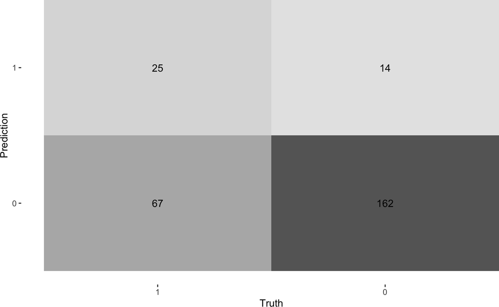

```r
logreg_fit %>%
  augment(new_data = malaria_train) %>%
  conf_mat(truth = severity, estimate = .pred_class) %>%
  autoplot(type = "heatmap")
```

We can also specify a set of metrics. In the following example, `malaria_metrics` is defined as a set of three metrics:

```r
malaria_metrics <- metric_set(accuracy, sensitivity, specificity)
```

And we can evaluate this set of metrics in the fitted model:

```r
augment(logreg_fit, new_data = malaria_train) %>%
  malaria_metrics(truth = severity, estimate = .pred_class) %>%
  kable(booktabs = TRUE)
```

| .metric | .estimator | .estimate |
| --- | --- | --- |
| accuracy | binary | 0.6977612 |
| sensitivity | binary | 0.2717391 |
| specificity | binary | 0.9204545 |

By calculating metrics on both the training and testing sets, we can assess whether the model is overfitting:

```r
logreg_fit %>%
  augment(malaria_train) %>%
  metrics(truth = severity, estimate = .pred_class)
```

```
## # A tibble: 2 × 3
##   .metric  .estimator .estimate
##   <chr>    <chr>          <dbl>
## 1 accuracy binary         0.698
## 2 kap      binary         0.223
```

```r
logreg_fit %>%
  augment(malaria_test) %>%
  metrics(truth = severity, estimate = .pred_class)
```

```
## # A tibble: 2 × 3
##   .metric  .estimator .estimate
##   <chr>    <chr>          <dbl>
## 1 accuracy binary        0.623
## 2 kap      binary        0.0994
```

This metrics use the 50% threshold to declare an event (if the estimated probability is above 0.5, we declare severity = 1 and 0 otherwise.)

What if we decide to set the probability to declare an event equals to 80%? Varying this threshold affects sensitivity and specificity metrics.

We can use ROC (receiver operator characteristic):

- x-axis: the false positive rate (1 - specificity)
- y-axis: the true positive rate (sensitivity)

so we have a scenario with sensitivity and specificity calculated at all possible thresholds.

The area under the ROC curve can be used as a metric.

```r
augment(logreg_fit, new_data = malaria_train) %>%
  roc_auc(truth = severity, .pred_1) %>%
  kable(booktabs = TRUE)
```

| .metric | .estimator | .estimate |
| --- | --- | --- |
| roc_auc | binary | 0.6818182 |

And select a few *slices* to see their values:

```r
augment(logreg_fit, new_data = malaria_train) %>%
  roc_curve(truth = severity, .pred_1) %>%
  slice(1, 20, 50, 80, 130) %>%
  kable(booktabs = TRUE)
```

| .threshold | specificity | sensitivity |
| --- | --- | --- |
| -Inf | 0.0000000 | 1.0000000 |
| 0.1301050 | 0.0965909 | 0.9891304 |
| 0.1965778 | 0.2500000 | 0.9565217 |
| 0.2495732 | 0.3352273 | 0.7934783 |
| 0.3296452 | 0.5681818 | 0.6956522 |

## 7.2 Cross-Validation

We will use 5 *folds* as an example. To resample the training data, we will use the `vfold_cv` command:

```r
set.seed(234)
malaria_folds <- malaria_train %>%
                vfold_cv(v = 5, strata = severity)
malaria_folds
```

```
## #  5-fold cross-validation using stratification
## # A tibble: 5 × 2
##   splits           id
##   <list>           <chr>
## 1 <split [213/55]> Fold1
## 2 <split [214/54]> Fold2
## 3 <split [215/53]> Fold3
## 4 <split [215/53]> Fold4
## 5 <split [215/53]> Fold5
```

Fitting the model on resamples:

```r
logreg_cv <- logreg_wf %>% fit_resamples(malaria_folds)
logreg_cv
```

```
## # Resampling results
## # 5-fold cross-validation using stratification
## # A tibble: 5 × 4
##   splits           id    .metrics         .notes
##   <list>           <chr> <list>           <list>
## 1 <split [213/55]> Fold1 <tibble [3 × 4]> <tibble [0 × 3]>
## 2 <split [214/54]> Fold2 <tibble [3 × 4]> <tibble [0 × 3]>
## 3 <split [215/53]> Fold3 <tibble [3 × 4]> <tibble [0 × 3]>
## 4 <split [215/53]> Fold4 <tibble [3 × 4]> <tibble [0 × 3]>
## 5 <split [215/53]> Fold5 <tibble [3 × 4]> <tibble [0 × 3]>
```

The `collect_metrics()` function extracts the metrics obtained in each resample and calculates the validation metric, generally through an average:

```r
logreg_cv %>%
  collect_metrics() %>%
  kable(booktabs = TRUE)
```

| .metric | .estimator | mean | n | std_err | .config |
| --- | --- | --- | --- | --- | --- |
| accuracy | binary | 0.6451699 | 5 | 0.0269456 | Preprocessor1_Model1 |
| brier_class | binary | 0.2425237 | 5 | 0.0118100 | Preprocessor1_Model1 |
| roc_auc | binary | 0.5408939 | 5 | 0.0364921 | Preprocessor1_Model1 |

To calculate a chosen set of metrics, you need to specify the set in the `metrics` argument within `fit_resamples`:

```r
logreg_cv <- fit_resamples(logreg_wf,
                 malaria_folds,
                 metrics = malaria_metrics)

logreg_cv %>%
  collect_metrics() %>%
  kable(booktabs = TRUE)
```

| .metric | .estimator | mean | n | std_err | .config |
| --- | --- | --- | --- | --- | --- |
| accuracy | binary | 0.6451699 | 5 | 0.0269456 | Preprocessor1_Model1 |
| sensitivity | binary | 0.2818713 | 5 | 0.0301978 | Preprocessor1_Model1 |
| specificity | binary | 0.8349206 | 5 | 0.0265037 | Preprocessor1_Model1 |

Through cross-validation, we evaluate the model’s performance only with the training data, without using the test data.

The metric obtained on the validation set can be taken as an estimate of the metric on the test set.

In case we need to save the predictions obtained in the cross-validation steps, we use `control_resamples`:

```r
ctrl_malaria <- control_resamples(save_pred = TRUE)

logreg_cv <- fit_resamples(logreg_wf,
               malaria_folds,
               control = ctrl_malaria)

logreg_preds <- collect_predictions(logreg_cv)
logreg_preds
```

```
## # A tibble: 268 × 7
##    .pred_class .pred_1 .pred_0 id     .row severity .config
##    <fct>         <dbl>   <dbl> <chr> <int> <fct>    <chr>
##  1 0            0.408    0.592 Fold1     1 0        Preprocessor1_Model1
##  2 0            0.0501   0.950 Fold1    14 0        Preprocessor1_Model1
##  3 0            0.438    0.562 Fold1    17 0        Preprocessor1_Model1
##  4 0            0.159    0.841 Fold1    18 0        Preprocessor1_Model1
##  5 0            0.353    0.647 Fold1    21 0        Preprocessor1_Model1
##  6 0            0.317    0.683 Fold1    24 0        Preprocessor1_Model1
##  7 0            0.310    0.690 Fold1    34 0        Preprocessor1_Model1
##  8 0            0.186    0.814 Fold1    35 0        Preprocessor1_Model1
##  9 0            0.141    0.859 Fold1    41 0        Preprocessor1_Model1
## 10 0            0.445    0.555 Fold1    49 0        Preprocessor1_Model1
## # ℹ 258 more rows
```

## 7.3 Decision Tree

Another model to consider is decision tree. Let’s consider the following example:

```r
tree_spec <- decision_tree(cost_complexity = 0.005) %>%
    set_mode("classification") %>%
    set_engine("rpart", model = TRUE)
tree_spec
```

```
## Decision Tree Model Specification (classification)
##
## Main Arguments:
##   cost_complexity = 0.005
##
## Engine-Specific Arguments:
##   model = TRUE
##
## Computational engine: rpart
```

The decision tree model does not require preprocessing, so we can use a workflow with the specified formula and the specified model:

```r
tree_wf <- workflow(severity ~ ., tree_spec)
tree_wf
```

```
## ══ Workflow ════════════════════════════════════════════════════════════════════
## Preprocessor: Formula
## Model: decision_tree()
##
## ── Preprocessor ────────────────────────────────────────────────────────────────
## severity ~ .
##
## ── Model ───────────────────────────────────────────────────────────────────────
## Decision Tree Model Specification (classification)
##
## Main Arguments:
##   cost_complexity = 0.005
##
## Engine-Specific Arguments:
##   model = TRUE
##
## Computational engine: rpart
```

And then fit with training data:

```r
tree_fit <- tree_wf %>% fit(data = malaria_train)
```

Visualization of the fitted tree model:

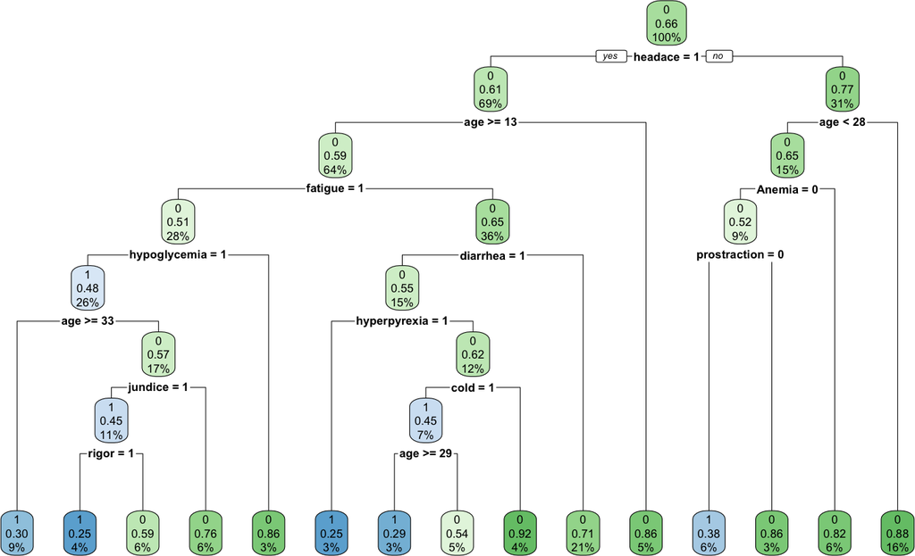

```r
library(rpart.plot)

tree_fit %>%
  extract_fit_engine() %>%
  rpart.plot()
```

Let’s then evaluate the performance of the decision tree using cross-validation:

```r
tree_cv <- tree_wf %>% fit_resamples(malaria_folds)

tree_cv %>% collect_metrics() %>%
  kable(booktabs = TRUE)
```

| .metric | .estimator | mean | n | std_err | .config |
| --- | --- | --- | --- | --- | --- |
| accuracy | binary | 0.5925469 | 5 | 0.0371328 | Preprocessor1_Model1 |
| brier_class | binary | 0.2635453 | 5 | 0.0144789 | Preprocessor1_Model1 |
| roc_auc | binary | 0.5468713 | 5 | 0.0305633 | Preprocessor1_Model1 |

## 7.4 Random Forest

We can also consider a random forest model. Here, we will use `set_engine` and add the argument `importance = "impurity"`, so we can have variable importance scores to help us understand which predictors are relevant.

```r
rf_spec <- rand_forest(trees = 1000) %>%
    set_mode("classification") %>%
    set_engine("ranger", importance = "impurity")
rf_spec
```

```
## Random Forest Model Specification (classification)
##
## Main Arguments:
##   trees = 1000
##
## Engine-Specific Arguments:
##   importance = impurity
##
## Computational engine: ranger
```

A simple workflow:

```r
rf_wf <- workflow(severity ~ ., rf_spec)
rf_wf
```

```
## ══ Workflow ════════════════════════════════════════════════════════════════════
## Preprocessor: Formula
## Model: rand_forest()
##
## ── Preprocessor ────────────────────────────────────────────────────────────────
## severity ~ .
##
## ── Model ───────────────────────────────────────────────────────────────────────
## Random Forest Model Specification (classification)
##
## Main Arguments:
##   trees = 1000
##
## Engine-Specific Arguments:
##   importance = impurity
##
## Computational engine: ranger
```

Evaluation of the metrics using cross-validation:

```r
set.seed(2024) #RF uses random numbers, so we need to set the seed
rf_cv <- rf_wf %>%
  fit_resamples(malaria_folds)

rf_cv %>% collect_metrics() %>%
  kable(booktabs = TRUE)
```

| .metric | .estimator | mean | n | std_err | .config |
| --- | --- | --- | --- | --- | --- |
| accuracy | binary | 0.6451674 | 5 | 0.0173482 | Preprocessor1_Model1 |
| brier_class | binary | 0.2315196 | 5 | 0.0070581 | Preprocessor1_Model1 |
| roc_auc | binary | 0.5242189 | 5 | 0.0408896 | Preprocessor1_Model1 |

## 7.5 A Set of Models

When we want to compare several models at the same time, it becomes a lot of work to do one at a time, as we showed previously.

`tidymodels` comes handy one more time. First, we can use the `workflow_set()` function to generate a set of workflows. The arguments of this function are:

- `preproc`: formulas, recipes
- `models`: models specified using `parsnip`

Here, we define a set of workflows of interest:

```r
wf_set <- workflow_set(preproc = list(rec1 = severity ~ .,
                                      rec2 = malaria_rec,
                                      rec1 = severity ~ .),
                       models = list(tree = tree_spec,
                                     logreg = logreg_spec,
                                     rf = rf_spec),
                       cross = FALSE)
```

To process this series of workflows, we use the `workflow_map()` function. We can evaluate the models with our chosen metrics using cross-validation by setting the option `fit_resamples`:

```r
wf_set %>%
  workflow_map("fit_resamples",
               resamples = malaria_folds,
               metrics = malaria_metrics,
               seed = 2024) %>%
  rank_results()
```

```
## # A tibble: 9 × 9
##   wflow_id    .config       .metric  mean std_err     n preprocessor model  rank
##   <chr>       <chr>         <chr>   <dbl>   <dbl> <int> <chr>        <chr> <int>
## 1 rec2_logreg Preprocessor… accura… 0.645  0.0269     5 recipe       logi…     1
## 2 rec2_logreg Preprocessor… sensit… 0.282  0.0302     5 recipe       logi…     1
## 3 rec2_logreg Preprocessor… specif… 0.835  0.0265     5 recipe       logi…     1
## 4 rec1_rf     Preprocessor… accura… 0.645  0.0173     5 formula      rand…     2
## 5 rec1_rf     Preprocessor… sensit… 0.108  0.0283     5 formula      rand…     2
## 6 rec1_rf     Preprocessor… specif… 0.926  0.0195     5 formula      rand…     2
## 7 rec1_tree   Preprocessor… accura… 0.593  0.0371     5 formula      deci…     3
## 8 rec1_tree   Preprocessor… sensit… 0.378  0.0731     5 formula      deci…     3
## 9 rec1_tree   Preprocessor… specif… 0.705  0.0473     5 formula      deci…     3
```

If the argument `cross = TRUE` the `workflow_set` makes a cross product of the recipes and models listed:

```r
workflow_set(preproc = list(rec1 = severity ~ .,
                            rec2 = malaria_rec),
             models = list(tree = tree_spec,
                           logreg = logreg_spec,
                           rf = rf_spec),
             cross = TRUE) %>%
  workflow_map("fit_resamples",
               resamples = malaria_folds,
               metrics = malaria_metrics,
               seed = 2024) %>%
  rank_results()
```

```
## # A tibble: 18 × 9
##    wflow_id    .config     .metric   mean std_err     n preprocessor model  rank
##    <chr>       <chr>       <chr>    <dbl>   <dbl> <int> <chr>        <chr> <int>
##  1 rec2_logreg Preprocess… accura… 0.645   0.0269     5 recipe       logi…     1
##  2 rec2_logreg Preprocess… sensit… 0.282   0.0302     5 recipe       logi…     1
##  3 rec2_logreg Preprocess… specif… 0.835   0.0265     5 recipe       logi…     1
##  4 rec1_logreg Preprocess… accura… 0.645   0.0249     5 formula      logi…     2
##  5 rec1_logreg Preprocess… sensit… 0.261   0.0269     5 formula      logi…     2
##  6 rec1_logreg Preprocess… specif… 0.846   0.0296     5 formula      logi…     2
##  7 rec1_rf     Preprocess… accura… 0.645   0.0173     5 formula      rand…     3
##  8 rec1_rf     Preprocess… sensit… 0.108   0.0283     5 formula      rand…     3
##  9 rec1_rf     Preprocess… specif… 0.926   0.0195     5 formula      rand…     3
## 10 rec2_rf     Preprocess… accura… 0.642   0.0163     5 recipe       rand…     4
## 11 rec2_rf     Preprocess… sensit… 0.0865  0.0127     5 recipe       rand…     4
## 12 rec2_rf     Preprocess… specif… 0.932   0.0214     5 recipe       rand…     4
## 13 rec1_tree   Preprocess… accura… 0.593   0.0371     5 formula      deci…     5
## 14 rec1_tree   Preprocess… sensit… 0.378   0.0731     5 formula      deci…     5
## 15 rec1_tree   Preprocess… specif… 0.705   0.0473     5 formula      deci…     5
## 16 rec2_tree   Preprocess… accura… 0.586   0.0326     5 recipe       deci…     6
## 17 rec2_tree   Preprocess… sensit… 0.391   0.0961     5 recipe       deci…     6
## 18 rec2_tree   Preprocess… specif… 0.688   0.0541     5 recipe       deci…     6
```

Let’s suppose the logistic regression model was chosen.

Let’s fit the model on training data and check performance on testing data:

```r
final_fit <- last_fit(logreg_wf,
                      malaria_split,
                      metrics = malaria_metrics)
```

Remember that the `malaria_split` object has information about the separation of original data into training and testing.

```r
final_fit
```

```
## # Resampling results
## # Manual resampling
## # A tibble: 1 × 6
##   splits           id               .metrics .notes   .predictions .workflow
##   <list>           <chr>            <list>   <list>   <list>       <list>
## 1 <split [268/69]> train/test split <tibble> <tibble> <tibble>     <workflow>
```

Metrics calculated for the **test** dataset:

```r
collect_metrics(final_fit)
```

```
## # A tibble: 3 × 4
##   .metric     .estimator .estimate .config
##   <chr>       <chr>          <dbl> <chr>
## 1 accuracy    binary         0.623 Preprocessor1_Model1
## 2 sensitivity binary         0.292 Preprocessor1_Model1
## 3 specificity binary         0.8   Preprocessor1_Model1
```

Predictions for the **test** dataset:

```r
collect_predictions(final_fit) %>%
  head()
```

```
## # A tibble: 6 × 5
##   .pred_class id                .row severity .config
##   <fct>       <chr>            <int> <fct>    <chr>
## 1 0           train/test split     1 0        Preprocessor1_Model1
## 2 0           train/test split     3 1        Preprocessor1_Model1
## 3 0           train/test split     7 0        Preprocessor1_Model1
## 4 0           train/test split     9 0        Preprocessor1_Model1
## 5 0           train/test split    17 0        Preprocessor1_Model1
## 6 0           train/test split    19 0        Preprocessor1_Model1
```

What information do we have in `final_fit`?

```r
extract_workflow(final_fit)
```

```
## ══ Workflow [trained] ══════════════════════════════════════════════════════════
## Preprocessor: Recipe
## Model: logistic_reg()
##
## ── Preprocessor ────────────────────────────────────────────────────────────────
## 1 Recipe Step
##
## • step_poly()
##
## ── Model ───────────────────────────────────────────────────────────────────────
##
## Call:  stats::glm(formula = ..y ~ ., family = ~"binomial", data = data)
##
## Coefficients:
##    (Intercept)             sex           fever            cold           rigor
##        2.36709        -0.29587        -0.07531        -0.35300        -0.11476
##        fatigue         headace   bitter_tongue       vomitting        diarrhea
##       -0.49982        -0.92269         0.26280        -0.31354        -0.40748
##     Convulsion          Anemia         jundice  cocacola_urine    hypoglycemia
##        0.48892         0.27191        -0.03444        -0.29044        -0.59601
##   prostraction    hyperpyrexia      age_poly_1      age_poly_2
##        0.81061        -0.02728        -0.89869         2.71010
##
## Degrees of Freedom: 267 Total (i.e. Null);  249 Residual
## Null Deviance:       344.7
## Residual Deviance: 316.8     AIC: 354.8
```

What are the parameter estimates of the final model?

```r
final_fit %>%
  extract_fit_parsnip() %>%
  tidy()
```

```
## # A tibble: 19 × 5
##    term           estimate std.error statistic  p.value
##    <chr>             <dbl>     <dbl>     <dbl>    <dbl>
##  1 (Intercept)      2.37       0.706    3.35   0.000805
##  2 sex             -0.296      0.289   -1.02   0.307
##  3 fever           -0.0753     0.321   -0.235  0.814
##  4 cold            -0.353      0.284   -1.24   0.214
##  5 rigor           -0.115      0.301   -0.381  0.703
##  6 fatigue         -0.500      0.289   -1.73   0.0841
##  7 headace         -0.923      0.332   -2.78   0.00538
##  8 bitter_tongue    0.263      0.288    0.914  0.361
##  9 vomitting       -0.314      0.512   -0.613  0.540
## 10 diarrhea        -0.407      0.288   -1.42   0.157
## 11 Convulsion       0.489      0.303    1.62   0.106
## 12 Anemia           0.272      0.291    0.933  0.351
## 13 jundice         -0.0344     0.295   -0.117  0.907
## 14 cocacola_urine  -0.290      0.282   -1.03   0.303
## 15 hypoglycemia    -0.596      0.452   -1.32   0.188
## 16 prostraction     0.811      0.356    2.28   0.0228
## 17 hyperpyrexia    -0.0273     0.420   -0.0649 0.948
## 18 age_poly_1      -0.899      2.37    -0.379  0.705
## 19 age_poly_2       2.71       2.39     1.13   0.256
```

# 8 Tuning

Some model characteristics cannot be estimated directly from the data.

We choose a logistic regression model, for example, and use the training data to obtain the model parameters.

However, some choices are made before fitting the model: will we use some quadratic form? interactions? What variables will we consider?

Some decisions must be made at the *recipe* stage and others must be made *within the model*.

For tuning, we can test different *workflows* and evaluate their performances with cross-validation.

## 8.1 Polynomial Logistic Regression

For a logistic regression model in which one of the variables, `age`, will be considered through a polynomial, we have the following recipe:

```r
malaria_rec <-
  recipe(severity ~ ., data = malaria_train) %>%
  step_poly(age, degree = tune())
```

Note that, above, we did not directly specify the degree of the polynomial. We will indicate that this hyperparameter needs to be tuned by using the `tune()` function.

With the recipe defined, let’s aggregate the information into a workflow:

```r
logregpol_wf <- workflow(malaria_rec, logreg_spec)
logregpol_wf
```

```
## ══ Workflow ════════════════════════════════════════════════════════════════════
## Preprocessor: Recipe
## Model: logistic_reg()
##
## ── Preprocessor ────────────────────────────────────────────────────────────────
## 1 Recipe Step
##
## • step_poly()
##
## ── Model ───────────────────────────────────────────────────────────────────────
## Logistic Regression Model Specification (classification)
##
## Engine-Specific Arguments:
##   family = binomial
##
## Computational engine: glm
```

We use the `tune_grid()` function, which calculates a set of metrics using cross-validation to evaluate performance on a pre-determined set (grid) of hyperparameters from a model or recipe:

```r
logregpol_res <- tune_grid(logregpol_wf,
                           malaria_folds,
                           grid = tibble(degree=1:6))
logregpol_res
```

```
## # Tuning results
## # 5-fold cross-validation using stratification
## # A tibble: 5 × 4
##   splits           id    .metrics          .notes
##   <list>           <chr> <list>            <list>
## 1 <split [213/55]> Fold1 <tibble [18 × 5]> <tibble [0 × 3]>
## 2 <split [214/54]> Fold2 <tibble [18 × 5]> <tibble [0 × 3]>
## 3 <split [215/53]> Fold3 <tibble [18 × 5]> <tibble [0 × 3]>
## 4 <split [215/53]> Fold4 <tibble [18 × 5]> <tibble [0 × 3]>
## 5 <split [215/53]> Fold5 <tibble [18 × 5]> <tibble [0 × 3]>
```

Presenting the results (average of the 5 *folds*) for each degree of polynomial (the tuning parameter/hyperparameter) considered:

```r
collect_metrics(logregpol_res)
```

```
## # A tibble: 18 × 7
##    degree .metric     .estimator  mean     n std_err .config
##     <int> <chr>       <chr>      <dbl> <int>   <dbl> <chr>
##  1      1 accuracy    binary     0.645     5  0.0249 Preprocessor1_Model1
##  2      1 brier_class binary     0.241     5  0.0113 Preprocessor1_Model1
##  3      1 roc_auc     binary     0.541     5  0.0383 Preprocessor1_Model1
##  4      2 accuracy    binary     0.645     5  0.0269 Preprocessor2_Model1
##  5      2 brier_class binary     0.243     5  0.0118 Preprocessor2_Model1
##  6      2 roc_auc     binary     0.541     5  0.0365 Preprocessor2_Model1
##  7      3 accuracy    binary     0.634     5  0.0235 Preprocessor3_Model1
##  8      3 brier_class binary     0.243     5  0.0113 Preprocessor3_Model1
##  9      3 roc_auc     binary     0.539     5  0.0336 Preprocessor3_Model1
## 10      4 accuracy    binary     0.630     5  0.0250 Preprocessor4_Model1
## 11      4 brier_class binary     0.245     5  0.0124 Preprocessor4_Model1
## 12      4 roc_auc     binary     0.544     5  0.0321 Preprocessor4_Model1
## 13      5 accuracy    binary     0.590     5  0.0294 Preprocessor5_Model1
## 14      5 brier_class binary     0.251     5  0.0121 Preprocessor5_Model1
## 15      5 roc_auc     binary     0.532     5  0.0313 Preprocessor5_Model1
## 16      6 accuracy    binary     0.612     5  0.0347 Preprocessor6_Model1
## 17      6 brier_class binary     0.251     5  0.0123 Preprocessor6_Model1
## 18      6 roc_auc     binary     0.530     5  0.0332 Preprocessor6_Model1
```

Graphical visualization using `autoplot()`:

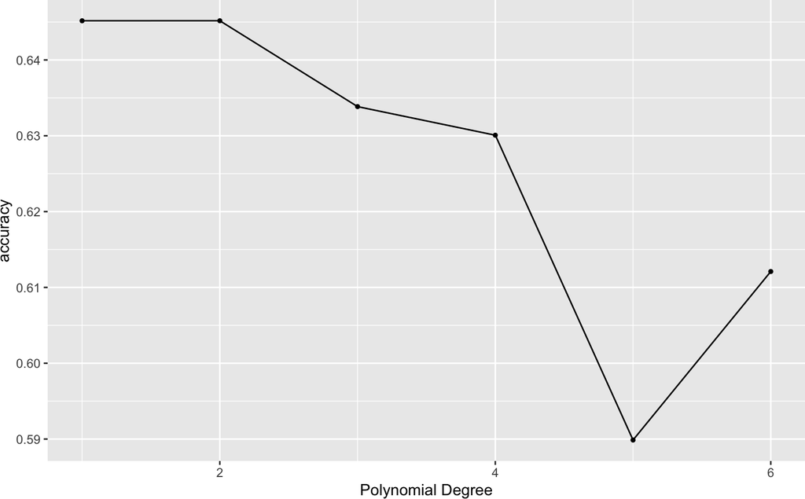

```r
autoplot(logregpol_res, metric = "accuracy")
```

Showing the 3 best results:

```r
show_best(logregpol_res,
          metric = "accuracy",
          n = 3)
```

```
## # A tibble: 3 × 7
##   degree .metric  .estimator  mean     n std_err .config
##    <int> <chr>    <chr>      <dbl> <int>   <dbl> <chr>
## 1      2 accuracy binary     0.645     5  0.0269 Preprocessor2_Model1
## 2      1 accuracy binary     0.645     5  0.0249 Preprocessor1_Model1
## 3      3 accuracy binary     0.634     5  0.0235 Preprocessor3_Model1
```

What if we fit another model, also with some other hyperparameter to be tuned? How to compare?

## 8.2 LASSO

We can fit a logistic regression using lasso regularization:

```r
logreglasso_spec <- logistic_reg(penalty = tune(), mixture = 1) %>%
  set_engine("glmnet", family = "binomial") %>%
  set_mode("classification")
```

`mixture = 1` specifies a pure lasso model and the `penalty` hyperparameter will be tuned using cross-validation.

We will not consider the polynomial for `age` in this workflow, so we can set it up directly with the formula and the specified model:

```r
logreglasso_wf <- workflow(severity ~ ., logreglasso_spec)
logreglasso_wf
```

```
## ══ Workflow ════════════════════════════════════════════════════════════════════
## Preprocessor: Formula
## Model: logistic_reg()
##
## ── Preprocessor ────────────────────────────────────────────────────────────────
## severity ~ .
##
## ── Model ───────────────────────────────────────────────────────────────────────
## Logistic Regression Model Specification (classification)
##
## Main Arguments:
##   penalty = tune()
##   mixture = 1
##
## Engine-Specific Arguments:
##   family = binomial
##
## Computational engine: glmnet
```

To evaluate the performance for multiple values of the hyperparameter using cross-validation:

```r
set.seed(2024)
logreglasso_res <-
  tune_grid(logreglasso_wf,
            resamples = malaria_folds,
            grid = 20,
            metrics = malaria_metrics)
```

Resulting metrics from cross-validation considering the grid values:

```r
logreglasso_res %>% collect_metrics()
```

```
## # A tibble: 60 × 7
##     penalty .metric     .estimator  mean     n std_err .config
##       <dbl> <chr>       <chr>      <dbl> <int>   <dbl> <chr>
##  1 2.77e-10 accuracy    binary     0.645     5  0.0249 Preprocessor1_Model01
##  2 2.77e-10 sensitivity binary     0.261     5  0.0269 Preprocessor1_Model01
##  3 2.77e-10 specificity binary     0.846     5  0.0296 Preprocessor1_Model01
##  4 3.45e-10 accuracy    binary     0.645     5  0.0249 Preprocessor1_Model02
##  5 3.45e-10 sensitivity binary     0.261     5  0.0269 Preprocessor1_Model02
##  6 3.45e-10 specificity binary     0.846     5  0.0296 Preprocessor1_Model02
##  7 1.17e- 9 accuracy    binary     0.645     5  0.0249 Preprocessor1_Model03
##  8 1.17e- 9 sensitivity binary     0.261     5  0.0269 Preprocessor1_Model03
##  9 1.17e- 9 specificity binary     0.846     5  0.0296 Preprocessor1_Model03
## 10 5.42e- 9 accuracy    binary     0.645     5  0.0249 Preprocessor1_Model04
## # ℹ 50 more rows
```

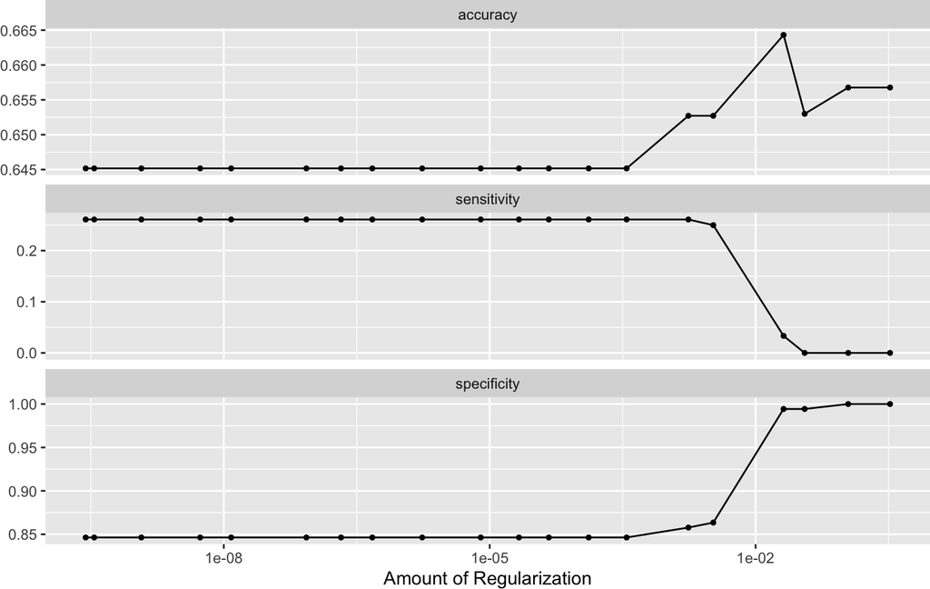

```r
autoplot(logreglasso_res)
```

The best result from cross-validation, considering the accuracy metric:

```r
show_best(logreglasso_res, metric = "accuracy", n = 1)
```

```
## # A tibble: 1 × 7
##   penalty .metric  .estimator  mean     n std_err .config
##     <dbl> <chr>    <chr>      <dbl> <int>   <dbl> <chr>
## 1  0.0207 accuracy binary     0.664     5 0.00640 Preprocessor1_Model17
```

## 8.3 Decision Tree

Below is a *workflow* for a decision tree with hyperparameter (`cost_complexity`) tuning.

First, the model is specified by including `tune()`:

```r
tree_spec <-
  decision_tree(
    cost_complexity = tune()
  ) %>%
  set_mode("classification") %>%
  set_engine("rpart", model = TRUE)
```

The *workflow*:

```r
tree_wf <- workflow(severity ~ ., tree_spec)
```

Let’s use `tune_grid()` to evaluate multiple values for the hyperparameter:

```r
tree_res <-
  tune_grid(tree_wf,
            resamples = malaria_folds,
            grid = 30,
            metrics = malaria_metrics)
```

It is possible to provide a `data.frame` in the `grid` option, to be more specific.

Metrics obtained through cross-validation considering the `grid` values:

```r
tree_res %>% collect_metrics()
```

```
## # A tibble: 90 × 7
##    cost_complexity .metric     .estimator  mean     n std_err .config
##              <dbl> <chr>       <chr>      <dbl> <int>   <dbl> <chr>
##  1        1.24e- 9 accuracy    binary     0.593     5  0.0371 Preprocessor1_Mod…
##  2        1.24e- 9 sensitivity binary     0.378     5  0.0731 Preprocessor1_Mod…
##  3        1.24e- 9 specificity binary     0.705     5  0.0473 Preprocessor1_Mod…
##  4        1.40e-10 accuracy    binary     0.593     5  0.0371 Preprocessor1_Mod…
##  5        1.40e-10 sensitivity binary     0.378     5  0.0731 Preprocessor1_Mod…
##  6        1.40e-10 specificity binary     0.705     5  0.0473 Preprocessor1_Mod…
##  7        2.22e- 4 accuracy    binary     0.593     5  0.0371 Preprocessor1_Mod…
##  8        2.22e- 4 sensitivity binary     0.378     5  0.0731 Preprocessor1_Mod…
##  9        2.22e- 4 specificity binary     0.705     5  0.0473 Preprocessor1_Mod…
## 10        5.45e- 9 accuracy    binary     0.593     5  0.0371 Preprocessor1_Mod…
## # ℹ 80 more rows
```

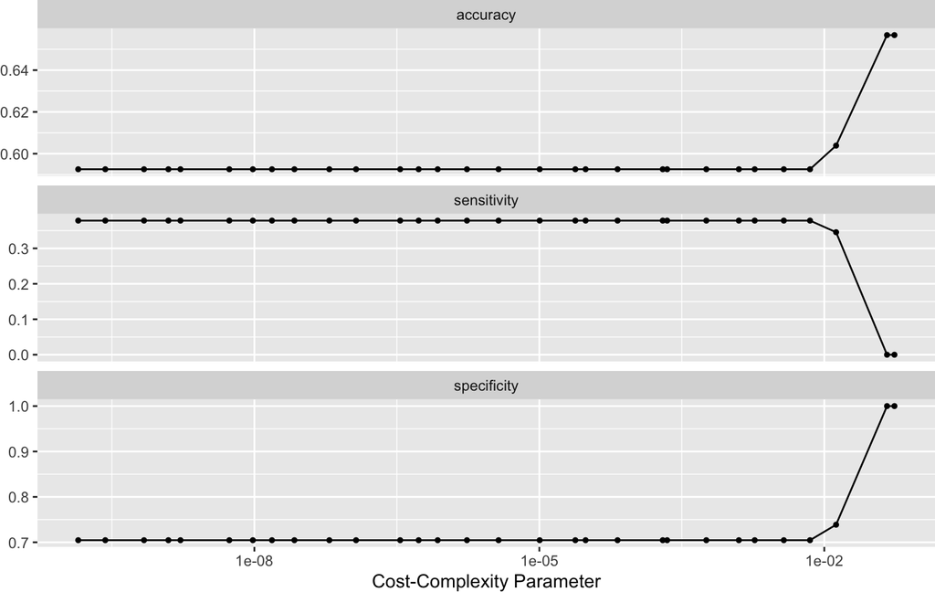

```r
autoplot(tree_res)
```

The best result from cross-validation, considering accuracy metric:

```r
show_best(tree_res, metric = "accuracy", n = 1)
```

```
## # A tibble: 1 × 7
##   cost_complexity .metric  .estimator  mean     n std_err .config
##             <dbl> <chr>    <chr>      <dbl> <int>   <dbl> <chr>
## 1          0.0457 accuracy binary     0.657     5 0.00243 Preprocessor1_Model09
```

## 8.4 Random Forest

A tuning parameter that is commonly chosen for random forest models is `mtry`, which is the number of predictors that will be randomly sampled at each split when creating the tree models.

For the `ranger` engine, the [default](https://parsnip.tidymodels.org/reference/details_rand_forest_ranger.html) is `floor(sqrt(ncol(x)))`.

Let’s use cross-validation to tune this parameter.

We start by specifying the model and including `tune()`:

```r
rf_spec <- rand_forest(trees = 1000,
                       mtry = tune()) %>%
    set_mode("classification") %>%
    set_engine("ranger", importance = "impurity")
rf_spec
```

```
## Random Forest Model Specification (classification)
##
## Main Arguments:
##   mtry = tune()
##   trees = 1000
##
## Engine-Specific Arguments:
##   importance = impurity
##
## Computational engine: ranger
```

The workflow:

```r
rf_wf <- workflow(severity ~ ., rf_spec)
rf_wf
```

```
## ══ Workflow ════════════════════════════════════════════════════════════════════
## Preprocessor: Formula
## Model: rand_forest()
##
## ── Preprocessor ────────────────────────────────────────────────────────────────
## severity ~ .
##
## ── Model ───────────────────────────────────────────────────────────────────────
## Random Forest Model Specification (classification)
##
## Main Arguments:
##   mtry = tune()
##   trees = 1000
##
## Engine-Specific Arguments:
##   importance = impurity
##
## Computational engine: ranger
```

Let’s use `tune_grid()` to evaluate the performance for multiple values of the hyperparameter using cross-validation:

```r
set.seed(2024)
rf_res <-
  tune_grid(rf_wf,
            resamples = malaria_folds,
            grid = 15,
            metrics = malaria_metrics)
```

Resulting metrics from cross-validation considering the grid values:

```r
rf_res %>% collect_metrics()
```

```
## # A tibble: 36 × 7
##     mtry .metric     .estimator  mean     n std_err .config
##    <int> <chr>       <chr>      <dbl> <int>   <dbl> <chr>
##  1    16 accuracy    binary     0.626     5  0.0266 Preprocessor1_Model01
##  2    16 sensitivity binary     0.226     5  0.0401 Preprocessor1_Model01
##  3    16 specificity binary     0.835     5  0.0307 Preprocessor1_Model01
##  4     5 accuracy    binary     0.638     5  0.0144 Preprocessor1_Model02
##  5     5 sensitivity binary     0.130     5  0.0268 Preprocessor1_Model02
##  6     5 specificity binary     0.903     5  0.0116 Preprocessor1_Model02
##  7    13 accuracy    binary     0.626     5  0.0177 Preprocessor1_Model03
##  8    13 sensitivity binary     0.194     5  0.0299 Preprocessor1_Model03
##  9    13 specificity binary     0.852     5  0.0144 Preprocessor1_Model03
## 10    15 accuracy    binary     0.612     5  0.0216 Preprocessor1_Model04
## # ℹ 26 more rows
```

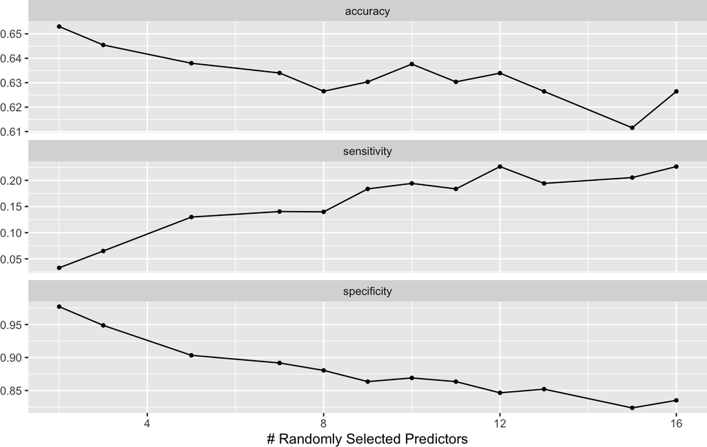

```r
autoplot(rf_res)
```

The best result from cross-validation, considering the accuracy metric:

```r
show_best(rf_res, metric = "accuracy", n = 1)
```

```
## # A tibble: 1 × 7
##    mtry .metric  .estimator  mean     n std_err .config
##   <int> <chr>    <chr>      <dbl> <int>   <dbl> <chr>
## 1     2 accuracy binary     0.653     5 0.00365 Preprocessor1_Model07
```

## 8.5 Fitting the chosen tuned model

Let’s assume, for instance, that between the four options (polynomial logistic regression, LASSO, decision tree and random forest), we decide to use the best tuned LASSO logistic regression.

We then need to select the model with the best performing hyperparameter, we do so by using the `select_best()` function:

```r
 best_acc <- select_best(logreglasso_res, metric = "accuracy")
 best_acc
```

```
## # A tibble: 1 × 2
##   penalty .config
##     <dbl> <chr>
## 1  0.0207 Preprocessor1_Model17
```

```r
final_lasso_fit <- logreglasso_wf %>%
   finalize_workflow(best_acc) %>%
   last_fit(malaria_split)
final_lasso_fit
```

```
## # Resampling results
## # Manual resampling
## # A tibble: 1 × 6
##   splits           id               .metrics .notes   .predictions .workflow
##   <list>           <chr>            <list>   <list>   <list>       <list>
## 1 <split [268/69]> train/test split <tibble> <tibble> <tibble>     <workflow>
```

Results on test set:

```r
final_lasso_fit %>% collect_metrics()
```

```
## # A tibble: 3 × 4
##   .metric     .estimator .estimate .config
##   <chr>       <chr>          <dbl> <chr>
## 1 accuracy    binary         0.638 Preprocessor1_Model1
## 2 roc_auc     binary         0.551 Preprocessor1_Model1
## 3 brier_class binary         0.226 Preprocessor1_Model1
```

For the selected final *workflow*, we can save all final adjustment steps (obtained using the training set):

```r
fitted_wf <- extract_workflow(final_lasso_fit)
fitted_wf
```

```
## ══ Workflow [trained] ══════════════════════════════════════════════════════════
## Preprocessor: Formula
## Model: logistic_reg()
##
## ── Preprocessor ────────────────────────────────────────────────────────────────
## severity ~ .
##
## ── Model ───────────────────────────────────────────────────────────────────────
##
## Call:  glmnet::glmnet(x = maybe_matrix(x), y = y, family = ~"binomial",      alpha = ~1)
##
##    Df %Dev   Lambda
## 1   0 0.00 0.074080
## 2   1 0.32 0.067500
## 3   2 0.71 0.061510
```

[output cut: 46 more lines]

Get predicted values for the test data:

```r
fitted_wf %>% augment(malaria_test)
```

```
## # A tibble: 69 × 21
##    .pred_class .pred_1 .pred_0   age   sex fever  cold rigor fatigue headace
##    <fct>         <dbl>   <dbl> <dbl> <dbl> <dbl> <dbl> <dbl>   <dbl>   <dbl>
##  1 0             0.481   0.519     3     1     1     1     0       1       1
##  2 0             0.480   0.520     3     0     1     1     1       1       1
##  3 0             0.272   0.728     4     0     1     1     1       1       0
##  4 0             0.392   0.608     5     0     1     0     1       1       1
##  5 0             0.262   0.738     9     1     1     1     1       0       0
##  6 0             0.364   0.636    10     0     1     0     0       0       1
##  7 0             0.333   0.667    11     1     0     0     1       1       1
##  8 0             0.282   0.718    14     1     0     1     0       0       1
##  9 0             0.267   0.733    14     1     0     0     0       0       1
## 10 0             0.364   0.636    15     0     1     0     0       0       1
## # ℹ 59 more rows
## # ℹ 11 more variables: bitter_tongue <dbl>, vomitting <dbl>, diarrhea <dbl>,
## #   Convulsion <dbl>, Anemia <dbl>, jundice <dbl>, cocacola_urine <dbl>,
## #   hypoglycemia <dbl>, prostraction <dbl>, hyperpyrexia <dbl>, severity <fct>
```

Results on the train set:

```r
fitted_wf %>%
  augment(malaria_train) %>%
  metrics(truth = severity, estimate = .pred_class)
```

```
## # A tibble: 2 × 3
##   .metric  .estimator .estimate
##   <chr>    <chr>          <dbl>
## 1 accuracy binary        0.664
## 2 kap      binary        0.0413
```

To obtain the estimates of the model:

```r
final_lasso_fit %>%
  extract_fit_parsnip() %>%
  tidy() %>%
  kable(booktabs = TRUE)
```

| term | estimate | penalty |
| --- | --- | --- |
| (Intercept) | 1.3951474 | 0.0206876 |
| age | 0.0000000 | 0.0206876 |
| sex | -0.0042964 | 0.0206876 |
| fever | 0.0000000 | 0.0206876 |
| cold | -0.1378722 | 0.0206876 |
| rigor | 0.0000000 | 0.0206876 |
| fatigue | -0.2747119 | 0.0206876 |
| headace | -0.5360916 | 0.0206876 |
| bitter_tongue | 0.0000000 | 0.0206876 |
| vomitting | 0.0000000 | 0.0206876 |
| diarrhea | -0.2005515 | 0.0206876 |
| Convulsion | 0.1348055 | 0.0206876 |
| Anemia | 0.0819064 | 0.0206876 |
| jundice | 0.0000000 | 0.0206876 |
| cocacola_urine | -0.0212551 | 0.0206876 |
| hypoglycemia | -0.2784257 | 0.0206876 |
| prostraction | 0.4542312 | 0.0206876 |
| hyperpyrexia | 0.0000000 | 0.0206876 |

## 8.6 Everything Everywhere All at Once

We can define a set of workflows and then evaluate it using `tune_grid`.

```r
wf_tune_set <- workflow_set(preproc = list(rec1 = severity ~ .,
                                           rec2 = malaria_rec,
                                           rec1 = severity ~ .,
                                           rec1 = severity ~ .),
                            models = list(tree = tree_spec,
                                          logreg = logreg_spec,
                                          rf = rf_spec,
                                          lasso_log = logreglasso_spec),
                            cross = FALSE)
```

```r
set.seed(2024)
wf_tune_res <-  wf_tune_set %>%
  workflow_map(resamples = malaria_folds,
               grid = 40,
               metrics = malaria_metrics,
               control = control_grid(save_pred = TRUE))
```

```r
tune_results <- wf_tune_res %>%
  collect_metrics()
tune_results
```

```
## # A tibble: 300 × 9
##    wflow_id  .config        preproc model .metric .estimator  mean     n std_err
##    <chr>     <chr>          <chr>   <chr> <chr>   <chr>      <dbl> <int>   <dbl>
##  1 rec1_tree Preprocessor1… formula deci… accura… binary     0.593     5  0.0371
##  2 rec1_tree Preprocessor1… formula deci… sensit… binary     0.378     5  0.0731
##  3 rec1_tree Preprocessor1… formula deci… specif… binary     0.705     5  0.0473
##  4 rec1_tree Preprocessor1… formula deci… accura… binary     0.593     5  0.0371
##  5 rec1_tree Preprocessor1… formula deci… sensit… binary     0.378     5  0.0731
##  6 rec1_tree Preprocessor1… formula deci… specif… binary     0.705     5  0.0473
##  7 rec1_tree Preprocessor1… formula deci… accura… binary     0.593     5  0.0371
##  8 rec1_tree Preprocessor1… formula deci… sensit… binary     0.378     5  0.0731
##  9 rec1_tree Preprocessor1… formula deci… specif… binary     0.705     5  0.0473
## 10 rec1_tree Preprocessor1… formula deci… accura… binary     0.611     5  0.0378
## # ℹ 290 more rows
```

Let’s select the best performing workflow, considering the accuracy:

```r
best_wf_id <- wf_tune_res %>%
  rank_results() %>%
  filter(.metric == "accuracy") %>%
  arrange(desc(mean)) %>%
  slice(1) %>%  # Select the best one
  pull(wflow_id)

best_wf_id
```

```
## [1] "rec1_rf"
```

Then, we can extract the best workflow as follows:

```r
best_workflow <- wf_tune_set %>%
  extract_workflow(best_wf_id)
```

To finalize the selected workflow fixing the hyperparameter with best performance:

```r
best_workflow_final <- best_workflow %>%
  finalize_workflow(
    wf_tune_res %>%
      extract_workflow_set_result(best_wf_id) %>%
      select_best(metric = "accuracy")
  )
best_workflow_final
```

```
## ══ Workflow ════════════════════════════════════════════════════════════════════
## Preprocessor: Formula
## Model: rand_forest()
##
## ── Preprocessor ────────────────────────────────────────────────────────────────
## severity ~ .
##
## ── Model ───────────────────────────────────────────────────────────────────────
## Random Forest Model Specification (classification)
##
## Main Arguments:
##   mtry = 1
##   trees = 1000
##
## Engine-Specific Arguments:
##   importance = impurity
##
## Computational engine: ranger
```

```r
final_wf_fit <-
  best_workflow_final %>%
  last_fit(malaria_split,
           metrics = malaria_metrics)
final_wf_fit
```

```
## # Resampling results
## # Manual resampling
## # A tibble: 1 × 6
##   splits           id               .metrics .notes   .predictions .workflow
##   <list>           <chr>            <list>   <list>   <list>       <list>
## 1 <split [268/69]> train/test split <tibble> <tibble> <tibble>     <workflow>
```

Results on test set:

```r
final_wf_fit %>% collect_metrics()
```

```
## # A tibble: 3 × 4
##   .metric     .estimator .estimate .config
##   <chr>       <chr>          <dbl> <chr>
## 1 accuracy    binary         0.652 Preprocessor1_Model1
## 2 sensitivity binary         0     Preprocessor1_Model1
## 3 specificity binary         1     Preprocessor1_Model1
```

For the selected final *workflow*, we save all final adjustment steps (obtained using the training set):

```r
fitted_wf <- extract_workflow(final_wf_fit)
fitted_wf
```

```
## ══ Workflow [trained] ══════════════════════════════════════════════════════════
## Preprocessor: Formula
## Model: rand_forest()
##
## ── Preprocessor ────────────────────────────────────────────────────────────────
## severity ~ .
##
## ── Model ───────────────────────────────────────────────────────────────────────
## Ranger result
##
## Call:
##  ranger::ranger(x = maybe_data_frame(x), y = y, mtry = min_cols(~1L,      x), num.trees = ~1000, importance = ~"impurity", num.threads = 1,      verbose = FALSE, seed = sample.int(10^5, 1), probability = TRUE)
##
## Type:                             Probability estimation
## Number of trees:                  1000
## Sample size:                      268
## Number of independent variables:  17
## Mtry:                             1
## Target node size:                 10
## Variable importance mode:         impurity
## Splitrule:                        gini
## OOB prediction error (Brier s.):  0.2271211
```

Get predicted values for the test data:

```r
#predict(fitted_wf, malaria_test[1:3,])
final_wf_fit %>% augment()
```

```
## # A tibble: 69 × 19
##    .pred_class   age   sex fever  cold rigor fatigue headace bitter_tongue
##    <fct>       <dbl> <dbl> <dbl> <dbl> <dbl>   <dbl>   <dbl>         <dbl>
##  1 0               3     1     1     1     0       1       1             1
##  2 0               3     0     1     1     1       1       1             0
##  3 0               4     0     1     1     1       1       0             0
##  4 0               5     0     1     0     1       1       1             1
##  5 0               9     1     1     1     1       0       0             1
##  6 0              10     0     1     0     0       0       1             0
##  7 0              11     1     0     0     1       1       1             0
##  8 0              14     1     0     1     0       0       1             1
##  9 0              14     1     0     0     0       0       1             1
## 10 0              15     0     1     0     0       0       1             1
## # ℹ 59 more rows
## # ℹ 10 more variables: vomitting <dbl>, diarrhea <dbl>, Convulsion <dbl>,
## #   Anemia <dbl>, jundice <dbl>, cocacola_urine <dbl>, hypoglycemia <dbl>,
## #   prostraction <dbl>, hyperpyrexia <dbl>, severity <fct>
```

Final *workflow*:

```r
fitted_wf %>%
  extract_fit_parsnip()
```

```
## parsnip model object
##
## Ranger result
##
## Call:
##  ranger::ranger(x = maybe_data_frame(x), y = y, mtry = min_cols(~1L,      x), num.trees = ~1000, importance = ~"impurity", num.threads = 1,      verbose = FALSE, seed = sample.int(10^5, 1), probability = TRUE)
##
## Type:                             Probability estimation
## Number of trees:                  1000
## Sample size:                      268
## Number of independent variables:  17
## Mtry:                             1
## Target node size:                 10
## Variable importance mode:         impurity
## Splitrule:                        gini
## OOB prediction error (Brier s.):  0.2271211
```

Visualization of the predictors importance:

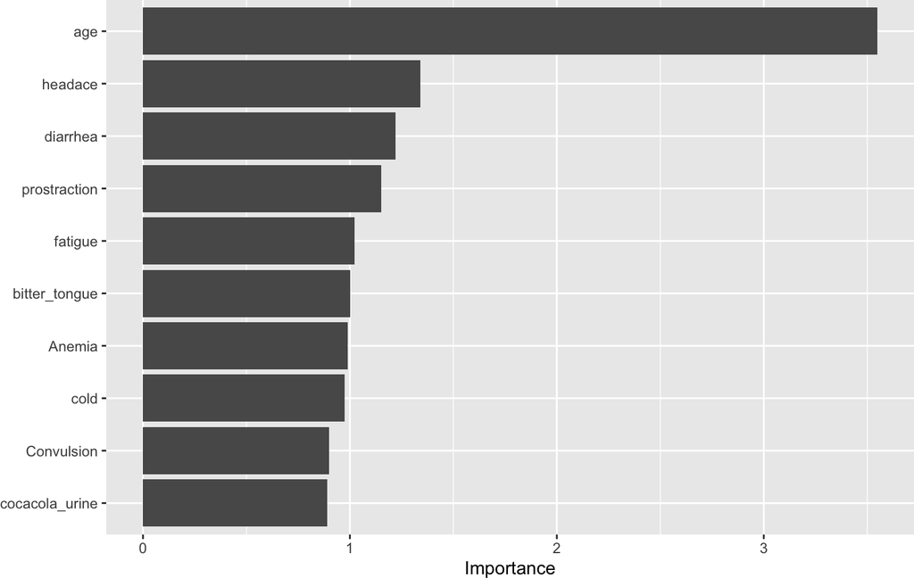

```r
library(vip)
final_wf_fit %>%
  extract_fit_parsnip() %>%
  vip(num_features = 10)
```

# References

Adeboye, Nureni Olawale, Olawale Victor Abimbola, and Sakinat Oluwabukola Folorunso. 2020. “Malaria Patients in Nigeria: Data Exploration Approach.” *Data in Brief* 28 (February): 104997. https://doi.org/10.1016/j.dib.2019.104997.

Hastie, Trevor, Robert Tibshirani, and Jerome Friedman. 2001. *The Elements of Statistical Learning*. Springer Series in Statistics. New York, NY, USA: Springer New York Inc.

James, Gareth, Daniela Witten, Trevor Hastie, and Robert Tibshirani. 2013. *An Introduction to Statistical Learning: With Applications in r*. Springer. https://www.statlearning.com.

Kuhn, M., and J. Silge. 2022. *Tidy Modeling with r*. O’Reilly Media. https://www.tmwr.org.